# 08_week slides

## Week 8: Fundamentals of Python Programming I

### POP77001 Computer Programming for Social Scientists

### Tom Paskhalis

##### 1 November 2022

##### Module website: tinyurl.com/POP77001

## Overview

- Python programs and their components
- Objects and operators
- Scalar and non-scalar types
- Indexing
- Methods and functions

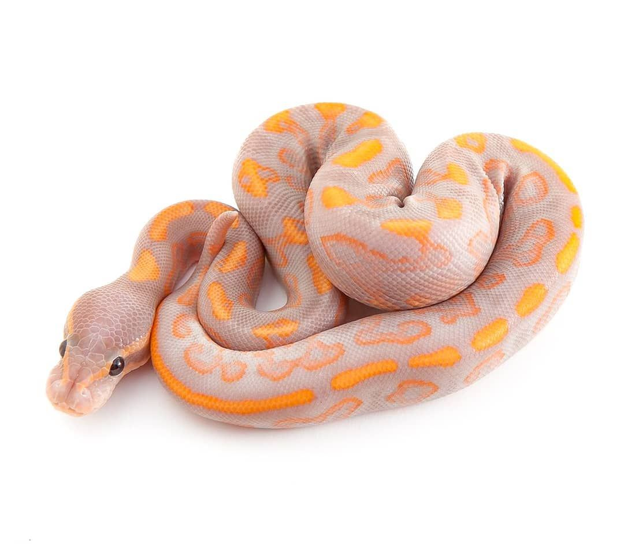

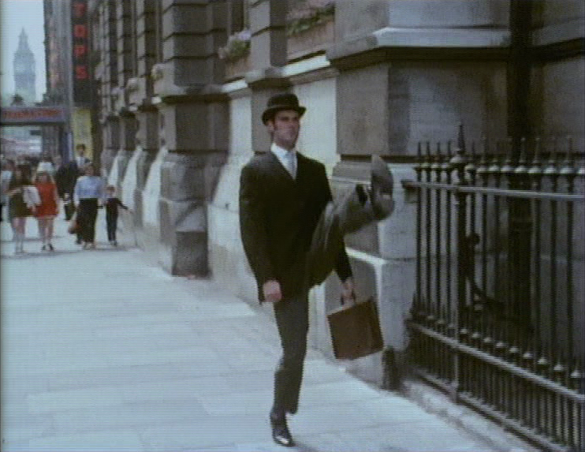

[figure not shown]

Source: [xkcd](https://xkcd.com/353/)

## Python background

Source: [Guido van Rossum](https://gvanrossum.github.io/), [Python Software Foundation](https://www.python.org/psf-landing/)

- Started as a side-project in 1989 by Guido van Rossum, BDFL (benevolent dictator for life) until 2018.
- Python 3, first released in 2008, is the current major version
- Python 2 support stopped on 1 January 2020

## The Zen of Python

```python
import this
```

```
The Zen of Python, by Tim Peters

Beautiful is better than ugly.
Explicit is better than implicit.
Simple is better than complex.
Complex is better than complicated.
Flat is better than nested.
Sparse is better than dense.
Readability counts.
Special cases aren't special enough to break the rules.
Although practicality beats purity.
Errors should never pass silently.
Unless explicitly silenced.
In the face of ambiguity, refuse the temptation to guess.
There should be one-- and preferably only one --obvious way to do it.
Although that way may not be obvious at first unless you're Dutch.
Now is better than never.
Although never is often better than *right* now.
If the implementation is hard to explain, it's a bad idea.
If the implementation is easy to explain, it may be a good idea.
Namespaces are one honking great idea -- let's do more of those!
```

## Python basics

- Python is an *interpreted* language (like R and Stata)
- Every program is executed one *command* (aka *statement*) at a time
- Which also means that work can be done interactively

```python
print("Hello World!")
```

```
Hello World!
```

## Python conceptual hierarchy

Python programs can be decomposed into modules, statements, expressions, and objects, as follows:

1. *Programs* are composed of *modules*
2. *Modules* contain *statements*
3. *Statements* contain *expressions*
4. *Expressions* create and process *objects*

## Python objects

- Everything that Python operates on is an *object*
- This includes numbers, strings, data structures, functions, etc.
- Eact object has a *type* (e.g. string or function) and internal data
- Objects can be *mutable* (e.g. list) and *immutable* (e.g. string)

## Operators

*Objects* and *operators* are combined to form *expressions*. Key *operators* are:

- Arithmetic (`+`, `-`, `*`, `**`, `/`, `//`, `%`)
- Boolean (`and`, `or`, `not`)
- Relational (`==`, `!=`, `>`, `>=`, `<`, `<=`)
- Assignment (`=`, `+=`, `-=`, `*=`, `/=`)
- Membership (`in`)

## Basic mathematical operations in Python

```python
1 + 1
```

```
2
```

```python
5 - 3
```

```
2
```

```python
6 / 2
```

```
3.0
```

```python
4 * 4
```

```
16
```

```python
# Exponentiation, Python comments start with #
2 ** 4
```

```
16
```

## Advanced mathematical operations in Python

```python
# Integer division (remainder is discarded)
7 // 3
```

```
2
```

```python
# Modulo operation (only remainder is retained)
7 % 3
```

```
1
```

## Basic logical operations in Python

```python
3 != 1 # Not equal
```

```
True
```

```python
3 > 3 # Greater than
```

```
False
```

```python
3 >= 3 # Greater than or equal
```

```
True
```

```python
False or True # True if either first or second operand is True, False otherwise
```

```
True
```

```python
3 > 3 or 3 >= 3 # Combining 3 Boolean expressions
```

```
True
```

## Assignment operations

Assignments create object references. *Target* (or *name*) on the left is assigned to *object* on the right.

```python
x = 3
```

```python
x
```

```
3
```

```python
x += 2 # Increment assignment, equivalent to x = x + 2
```

```python
x
```

```
5
```

## Assignment vs Comparison Operators

As `=` (assignment) and `==` (equality comparison) operators appear very similar, they sometime can create confusion.

```python
x = 3
```

```python
x
```

```
3
```

```python
x == 3
```

```
True
```

## Membership operations

Operator `in` returns `True` if an object of the left side is in a sequence on the right.

```python
'a' in 'abc'
```

```
True
```

```python
3 in [1, 2, 3] # [1,2,3] is a list
```

```
True
```

```python
3 not in [1, 2, 3]
```

```
False
```

## Object types

Python objects can have *scalar* and *non-scalar* types. Scalar objects are indivisible.

4 main types of scalar objects in Python:

- Integer (`int`)
- Real number (`float`)
- Boolean (`bool`)
- Null value (`None`)

## Scalar types

```python
type(7)
```

```
int
```

```python
type(3.14)
```

```
float
```

```python
type(True)
```

```
bool
```

```python
type(None) # None is the only object of NoneType
```

```
NoneType
```

```python
int(3.14) # Scalar type conversion (casting)
```

```
3
```

## Non-scalar types

In contrast to scalars, non-scalar objects, *sequences*, have some internal structure. This allows indexing, slicing and other interesting operations.

Most common sequences in Python are:

- String (`str`) - *immutable* ordered sequence of characters
- Tuple (`tuple`) - *immutable* ordered sequence of elements
- List (`list`) - *mutable* ordered sequence of elements
- Set (`set`) - *mutable* unordered collection of unique elements
- Dictionary (`dict`) - *mutable* unordered collection of key-value pairs

## Examples of non-scalar types

```python
s = 'time flies like a banana'
t = (0, 'one', 1, 2)
l = [0, 'one', 1, 2]
o = {'apple', 'banana', 'watermelon'}
d = {'apple': 150.0, 'banana': 120.0, 'watermelon': 3000.0}
```

```python
type(s)
```

```
str
```

```python
type(t)
```

```
tuple
```

```python
type(l)
```

```
list
```

```python
type(o)
```

```
set
```

```python
type(d)
```

```
dict
```

## Indexing and subsetting in Python

- *Indexing* can be used to subset individual elements from a sequence
- *Slicing* can be used to extract sub-sequence of arbitrary length
- Use square brackets `[]` to supply the index (indices) of elements:

```
object[index]
```

## Indexing in Python starts from 0

[figure not shown]

Source: [xkcd](https://xkcd.com/163/)  
Extra: [Why Python uses 0-based indexing by Guido van Rossum](https://python-history.blogspot.com/2013/10/why-python-uses-0-based-indexing.html)  
Extra: [Why numbering should start at zero by Edsger Dijkstra](https://www.cs.utexas.edu/users/EWD/transcriptions/EWD08xx/EWD831.html)

## Strings

```python
s
```

```
'time flies like a banana'
```

```python
len(s) # length of string (including whitespaces)
```

```
24
```

```python
s[0] # Subset 1st element (indexing in Python starts from zero!)
```

```
't'
```

```python
s[5:] # Subset all elements starting from 6th
```

```
'flies like a banana'
```

```python
s + '!' # Strings can be concatenated together
```

```
'time flies like a banana!'
```

## Objects have methods

- Python objects of built-in types have *methods* associated with them
- They can be thought of function-like objects
- However, their syntax is `object.method()` as opposed to `function(object)`

```python
len(s) # Function
```

```
24
```

```python
s.upper() # Method (makes string upper-case)
```

```
'TIME FLIES LIKE A BANANA'
```

## String methods

Some examples of methods associated with strings. More details [here](https://docs.python.org/3/library/stdtypes.html#string-methods).

```python
s.capitalize() # Note that only the first character gets capitalized
```

```
'Time flies like a banana'
```

```python
s.split(sep = ' ') # Here we supply an argument 'sep' to our methods call
```

```
['time', 'flies', 'like', 'a', 'banana']
```

```python
s.replace(' ', '-') # Arguments can also be matched by position, not just name
```

```
'time-flies-like-a-banana'
```

```python
'-'.join(s.split(sep = ' ')) # Methods calls can be nested within each other
```

```
'time-flies-like-a-banana'
```

## Tuples

```python
t # Tuples can contain elements of different types
```

```
(0, 'one', 1, 2)
```

```python
len(t)
```

```
4
```

```python
t[1:]
```

```
('one', 1, 2)
```

```python
t + ('three', 5) # Like strings tuples can be concatenated
```

```
(0, 'one', 1, 2, 'three', 5)
```

## Lists

```python
l # Like tuples lists can contain elements of different types
```

```
[0, 'one', 1, 2]
```

```python
l[1] = 1 # Unlike tuples lists are mutable
```

```python
l
```

```
[0, 1, 1, 2]
```

```python
t[1] = 1 # Compare to tuple
```

```
---------------------------------------------------------------------------
TypeError                                 Traceback (most recent call last)
<ipython-input-54-4e4114da061e> in <module>
----> 1 t[1] = 1 # Compare to tuple

TypeError: 'tuple' object does not support item assignment
```

## Indexing and slicing lists

```python
l
```

```
[0, 1, 1, 2]
```

```python
l[1:] # Subset all elements starting from 2nd
```

```
[1, 1, 2]
```

```python
l[-1] # Subset the last element
```

```
2
```

```python
l[::2] # Subset every second element, list[start:stop:step]
```

```
[0, 1]
```

```python
l[::-1] # Subset all elements in reverse order
```

```
[2, 1, 1, 0]
```

## Sets

```python
o
```

```
{'apple', 'banana', 'watermelon'}
```

```python
{'apple', 'apple', 'banana', 'watermelon'} # Sets retain only unique values
```

```
{'apple', 'banana', 'watermelon'}
```

```python
{'apple'} < o # Sets can be compared (e.g. one being subset of another)
```

```
True
```

```python
o[1] # Unlike strings, tuples and lists, sets are unordered
```

```
---------------------------------------------------------------------------
TypeError                                 Traceback (most recent call last)
<ipython-input-63-6a3d97725b65> in <module>
----> 1 o[1] # Unlike strings, tuples and lists, sets are unordered

TypeError: 'set' object is not subscriptable
```

## Set methods in Python

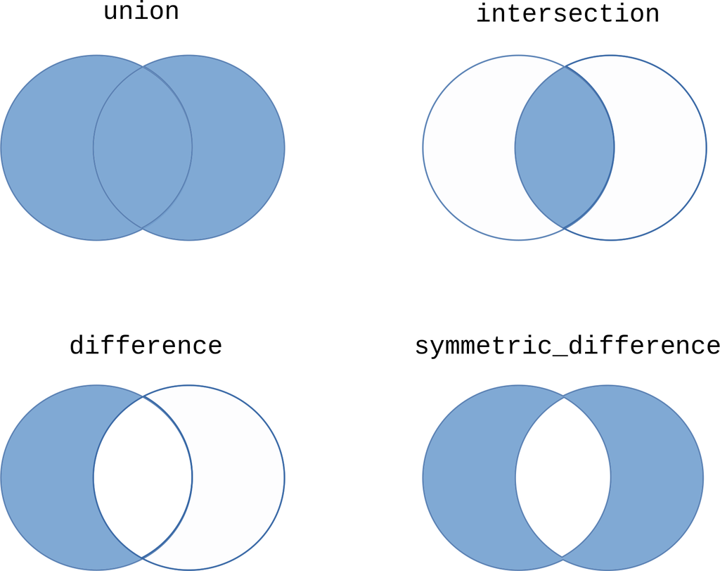

## Set methods example

[figure not shown]

Source: [Wikipedia](https://en.wikipedia.org/w/index.php?title=File:Supranational_European_Bodies-en.svg)

## Set methods example continued

```python
nordic = {'Denmark', 'Iceland', 'Finland', 'Norway', 'Sweden'}
eu = {'Denmark', 'Finland', 'Sweden'}
krones = {'Denmark', 'Sweden'}
```

```python
euro = eu.difference(krones) # Same can expressed using infix operators `eu - krones`
euro
```

```
{'Finland'}
```

```python
efta = nordic.difference(eu).union({'Liechtenstein', 'Switzerland'}) # Methods calls can also be 'chained'
efta
```

```
{'Iceland', 'Liechtenstein', 'Norway', 'Switzerland'}
```

```python
efta.intersection(nordic) # efta & nordic
```

```
{'Iceland', 'Norway'}
```

```python
schengen = efta.union(eu) # efta | eu
schengen
```

```
{'Denmark',
 'Finland',
 'Iceland',
 'Liechtenstein',
 'Norway',
 'Sweden',
 'Switzerland'}
```

## Dictionaries

```python
d # key:value pair, fruit_name:average_weight
```

```
{'apple': 150.0, 'banana': 120.0, 'watermelon': 3000.0}
```

```python
d['apple'] # Unlike strings, tuples and lists, dictionaries are indexed by 'keys'
```

```
150.0
```

```python
d[0] # Rather than integers
```

```
---------------------------------------------------------------------------
KeyError                                  Traceback (most recent call last)
<ipython-input-71-3cd4cfa8b308> in <module>
----> 1 d[0] # Rather than integers

KeyError: 0
```

```python
d['strawberry'] = 12.0 # They are, however, mutable like lists and sets
d
```

```
{'apple': 150.0, 'banana': 120.0, 'watermelon': 3000.0, 'strawberry': 12.0}
```

## Conversion between non-scalar types

```python
t ## Tuple
```

```
(0, 'one', 1, 2)
```

```python
list(t) ## Convert to list with a `list` function
```

```
[0, 'one', 1, 2]
```

```python
[x for x in t] ## List comprehesion, [expr for elem in iterable if test]
```

```
[0, 'one', 1, 2]
```

```python
set([0, 1, 1, 2]) ## Conversion to set retains only unique values
```

```
{0, 1, 2}
```

## None value

- `None` is a Python null object
- It is often used to initialize objects
- And it is a return value in some functions (more on that later)

```python
# Initialization of some temporary variable, which can re-assigned to another value later
tmp = None
```

```python
# Here we are initializing a list of length 10
tmp_l = [None] * 10
tmp_l
```

```
[None, None, None, None, None, None, None, None, None, None]
```

```python
None == None
```

```
True
```

## Aliasing vs copying in Python

- Assignment binds the varible name on the left of `=` sign to the object of certain type on the right.
- But the same object can have different names.
- Operations on immutable types typically overwrite the object if it gets modified.
- But for mutable objects (lists, sets, dictionaries) this can create hard-to-track problems.

## Example of aliasing/copying for immutable types

```python
x = 'test' # Object of type string is assinged to variable 'x'
x
```

```
'test'
```

```python
y = x # y is created an alias (alternative name) of x
y
```

```
'test'
```

```python
x = 'rest' # Another object of type string is assigned to 'x'
x
```

```
'rest'
```

```python
y
```

```
'test'
```

## Example of aliasing/copying for mutable types

```python
d
```

```
{'apple': 150.0, 'banana': 120.0, 'watermelon': 3000.0, 'strawberry': 12.0}
```

```python
d1 = d # Just an alias
d2 = d.copy() # Create a copy
d['watermelon'] = 500 # Modify original dictionary
```

```python
d1
```

```
{'apple': 150.0, 'banana': 120.0, 'watermelon': 500, 'strawberry': 12.0}
```

```python
d2
```

```
{'apple': 150.0, 'banana': 120.0, 'watermelon': 3000.0, 'strawberry': 12.0}
```

## Summary of built-in object types in Python

| Type | Description | Scalar | Mutability | Order |
| --- | --- | --- | --- | --- |
| `int` | integer | scalar | immutable |  |
| `float` | real number | scalar | immutable |  |
| `bool` | Boolean | scalar | immutable |  |
| `None` | Python 'Null' | scalar | immutable |  |
| `str` | string | non-scalar | immutable | ordered |
| `tuple` | tuple | non-scalar | immutable | ordered |
| `list` | list | non-scalar | mutable | ordered |
| `set` | set | non-scalar | mutable | unordered |
| `dict` | dictionary | non-scalar | mutable | unordered |

Extra: [Extensive Python documentation on built-it types](https://docs.python.org/3/library/stdtypes.html)

## Modules

- Python's power lies in its extensibility
- This is usually achieved by loading additional modules (libraries)
- Module can be just a `.py` file that you import into your program (script)
- However, often this refers to external libraries installed using `pip` or `conda`
- Standard Python installation also includes a number of modules (full list [here](https://docs.python.org/3/library/index.html))

## Basic statistical operations

```python
import statistics # Standard Python module
fib = [0, 1, 1, 2, 3, 5]
```

```python
statistics.mean(fib) # Mean
```

```
2
```

```python
statistics.median(fib) # Median
```

```
1.5
```

```python
statistics.mode(fib) # Mode
```

```
1
```

```python
statistics.stdev(fib) # Standard deviation
```

```
1.7888543819998317
```

## Help!

Python has an inbuilt help facility which provides more information about any object:

```python
?s
```

```python
help(s.join)
```

```
Help on built-in function join:

join(iterable, /) method of builtins.str instance
    Concatenate any number of strings.

    The string whose method is called is inserted in between each given string.
    The result is returned as a new string.

    Example: '.'.join(['ab', 'pq', 'rs']) -> 'ab.pq.rs'
```

- The quality of the documentation varies hugely across libraries
- [Stackoverflow](https://stackoverflow.com/) is a good resource for many standard tasks
- For custom packages it is often helpful to check the **issues** page on the [GitHub](https://github.com/)
- E.g. for `pandas`: https://github.com/pandas-dev/pandas/issues
- Or, indeed, any search engine [#LMDDGTFY](https://lmddgtfy.net/)

## Next

- Tutorial: Python objects, types, basic operations and methods
- Next week: Control flow and functions in Python